# The Pandas Library

The pandas library contains useful functions for reading and manipulating data. It organizes the CSV file into a data frame. In this notebook we will use pandas to read in our data and explore it.

## Palmer Penguins Data

We will use the penguins_size dataset, compiled by [Alison Horst](https://allisonhorst.github.io/palmerpenguins/)

This is data about three types of penguins that were studied in Antarctica.

The data we are using is available at [Parul Pandey's Kaggle page](https://www.kaggle.com/parulpandey/palmer-archipelago-antarctica-penguin-data?select=penguins_size.csv)

Select the penguins_size.csv file and click to download, and save it in the same folder as this notebook so that you can read it in easily.

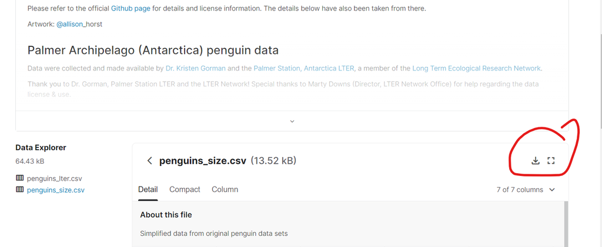

## Using Pandas

To use the pandas library, we have to import it. We usually use **pd** as the alias to refer to it as a shortcut.

```python
import pandas as pd
```

Now we can use the pandas operation to read the csv file we have saved. If it is in your current working directory, you don't have to specify the folder path.

```python
# Read the data from the csv file into a pandas dataframe called df.
df = pd.read_csv('penguins_size.csv')
```

Let's have a look at the first five row using the head() operation on the dataframe.

```python
df.head()
```

|  | species | island | culmen_length_mm | culmen_depth_mm | flipper_length_mm | body_mass_g | sex |
| --- | --- | --- | --- | --- | --- | --- | --- |
| 0 | Adelie | Torgersen | 39.1 | 18.7 | 181.0 | 3750.0 | MALE |
| 1 | Adelie | Torgersen | 39.5 | 17.4 | 186.0 | 3800.0 | FEMALE |
| 2 | Adelie | Torgersen | 40.3 | 18.0 | 195.0 | 3250.0 | FEMALE |
| 3 | Adelie | Torgersen | NaN | NaN | NaN | NaN | NaN |
| 4 | Adelie | Torgersen | 36.7 | 19.3 | 193.0 | 3450.0 | FEMALE |

This also gives us a look at the data that we have, nicely formatted by pandas. We can see that in row 3 there is missing data for some of the columns.

```python
# Show more rows by specifying the number required
df.head(10)
```

|  | species | island | culmen_length_mm | culmen_depth_mm | flipper_length_mm | body_mass_g | sex |
| --- | --- | --- | --- | --- | --- | --- | --- |
| 0 | Adelie | Torgersen | 39.1 | 18.7 | 181.0 | 3750.0 | MALE |
| 1 | Adelie | Torgersen | 39.5 | 17.4 | 186.0 | 3800.0 | FEMALE |
| 2 | Adelie | Torgersen | 40.3 | 18.0 | 195.0 | 3250.0 | FEMALE |
| 3 | Adelie | Torgersen | NaN | NaN | NaN | NaN | NaN |
| 4 | Adelie | Torgersen | 36.7 | 19.3 | 193.0 | 3450.0 | FEMALE |
| 5 | Adelie | Torgersen | 39.3 | 20.6 | 190.0 | 3650.0 | MALE |
| 6 | Adelie | Torgersen | 38.9 | 17.8 | 181.0 | 3625.0 | FEMALE |
| 7 | Adelie | Torgersen | 39.2 | 19.6 | 195.0 | 4675.0 | MALE |
| 8 | Adelie | Torgersen | 34.1 | 18.1 | 193.0 | 3475.0 | NaN |
| 9 | Adelie | Torgersen | 42.0 | 20.2 | 190.0 | 4250.0 | NaN |

```python
# tail() operation shows us the last few rows
df.tail()
```

|  | species | island | culmen_length_mm | culmen_depth_mm | flipper_length_mm | body_mass_g | sex |
| --- | --- | --- | --- | --- | --- | --- | --- |
| 339 | Gentoo | Biscoe | NaN | NaN | NaN | NaN | NaN |
| 340 | Gentoo | Biscoe | 46.8 | 14.3 | 215.0 | 4850.0 | FEMALE |
| 341 | Gentoo | Biscoe | 50.4 | 15.7 | 222.0 | 5750.0 | MALE |
| 342 | Gentoo | Biscoe | 45.2 | 14.8 | 212.0 | 5200.0 | FEMALE |
| 343 | Gentoo | Biscoe | 49.9 | 16.1 | 213.0 | 5400.0 | MALE |

This shows that there are 344 rows of data (indexed from 0 to 343). You can get information about the data frame using other operations:

```python
# Get basic info about the data frame
df.info()
```

```
<class 'pandas.core.frame.DataFrame'>
RangeIndex: 344 entries, 0 to 343
Data columns (total 7 columns):
 #   Column             Non-Null Count  Dtype
---  ------             --------------  -----
 0   species            344 non-null    object
 1   island             344 non-null    object
 2   culmen_length_mm   342 non-null    float64
 3   culmen_depth_mm    342 non-null    float64
 4   flipper_length_mm  342 non-null    float64
 5   body_mass_g        342 non-null    float64
 6   sex                334 non-null    object
dtypes: float64(4), object(3)
memory usage: 18.9+ KB
```

You can see from the information shown that there are 344 rows and 7 columns in the data. However, for some of the columns, they are non-null, indicating that there are missing values.

```python
# Basic descriptive statistics

df.describe()
```

|  | culmen_length_mm | culmen_depth_mm | flipper_length_mm | body_mass_g |
| --- | --- | --- | --- | --- |
| count | 342.000000 | 342.000000 | 342.000000 | 342.000000 |
| mean | 43.921930 | 17.151170 | 200.915205 | 4201.754386 |
| std | 5.459584 | 1.974793 | 14.061714 | 801.954536 |
| min | 32.100000 | 13.100000 | 172.000000 | 2700.000000 |
| 25% | 39.225000 | 15.600000 | 190.000000 | 3550.000000 |
| 50% | 44.450000 | 17.300000 | 197.000000 | 4050.000000 |
| 75% | 48.500000 | 18.700000 | 213.000000 | 4750.000000 |
| max | 59.600000 | 21.500000 | 231.000000 | 6300.000000 |

### Exploring by columns

You can get a list of the columns in the dataset.

```python
df.columns
```

```
Index(['species', 'island', 'culmen_length_mm', 'culmen_depth_mm',
       'flipper_length_mm', 'body_mass_g', 'sex'],
      dtype='object')
```

Then you can apply the describe() function on a specific column, even if it is non-numeric. This shows the information about the column: the number of values, how many unique values and the value with the highest frequency.

```python
# You can refer to the data in the columns using the name of the column
# These three ways equivalent,

df["species"].describe()
df['species'].describe()
df.species.describe()
```

```
count        344
unique         3
top       Adelie
freq         152
Name: species, dtype: object
```

Another quick way of checking how many observations of each species there are is to use value_counts()

```python
df["species"].value_counts()
```

```
Adelie       152
Gentoo       124
Chinstrap     68
Name: species, dtype: int64
```

### Groupings using groupby

When we have many categories of data, we would like to compare values between the categories The groupby() function can be used group the data by a specific column, for example if we want to find the means for the numeric values for each species:

```python
# find the mean for each group of species
df.groupby("species").mean()
```

| species | culmen_length_mm | culmen_depth_mm | flipper_length_mm | body_mass_g |
| --- | --- | --- | --- | --- |
| Adelie | 38.791391 | 18.346358 | 189.953642 | 3700.662252 |
| Chinstrap | 48.833824 | 18.420588 | 195.823529 | 3733.088235 |
| Gentoo | 47.504878 | 14.982114 | 217.186992 | 5076.016260 |

This calculates the mean of each of the numeric values, for each group of species. You can also count the number of values recorded

```python
# Counting the number of data values for each column using count()
print("Count of data values for each species")
print(df.groupby(['species']).count())

# Count the number of unique values for each column ising nunique()
print("Count of unique data values for each species")
print(df.groupby(['species']).nunique())
```

```
Count of data values for each species
           island  culmen_length_mm  culmen_depth_mm  flipper_length_mm  \
species
Adelie        152               151              151                151
Chinstrap      68                68               68                 68
Gentoo        124               123              123                123

           body_mass_g  sex
species
Adelie             151  146
Chinstrap           68   68
Gentoo             123  120
Count of unique data values for each species
           island  culmen_length_mm  culmen_depth_mm  flipper_length_mm  \
species
Adelie          3                78               49                 32
Chinstrap       1                55               33                 25
Gentoo          1                75               39                 25

           body_mass_g  sex
species
Adelie              55    2
Chinstrap           34    2
Gentoo              47    3
```

You can add another level to group by, for example, if we want to calculate the mean by species, then sex.

```python
#adding another column to group by
df.groupby(["species","sex"]).mean()
```

| species | sex | culmen_length_mm | culmen_depth_mm | flipper_length_mm | body_mass_g |
| --- | --- | --- | --- | --- | --- |
| Adelie | FEMALE | 37.257534 | 17.621918 | 187.794521 | 3368.835616 |
|  | MALE | 40.390411 | 19.072603 | 192.410959 | 4043.493151 |
| Chinstrap | FEMALE | 46.573529 | 17.588235 | 191.735294 | 3527.205882 |
|  | MALE | 51.094118 | 19.252941 | 199.911765 | 3938.970588 |
| Gentoo | . | 44.500000 | 15.700000 | 217.000000 | 4875.000000 |
|  | FEMALE | 45.563793 | 14.237931 | 212.706897 | 4679.741379 |
|  | MALE | 49.473770 | 15.718033 | 221.540984 | 5484.836066 |

This shows the mean values by each species, then they are further grouped into the different levels by sex. However for Gentoo there are actually three types of values for the 'sex' column. We'll have to try to manage that later.

You can even try to group further, though groupings are generally only meaningful for categorical values.

```python
data.groupby(["species","sex","island"]).mean()
```

[output not shown]

## Exercises

Let's try out these operations with the Iris data set from datahub labeled as [Iris](https://datahub.io/machine-learning/iris#resource-iris).

Download the iris_csv.csv dataset into your working directory and then proceed with the questions below.

```python
# We should always start with the import, although it may have been run above
import pandas as pd
```

```python
# read the data into a dataframe called irisdf
irisdf = pd.read_csv('iris_csv.csv')
```

```python
irisdf.head()
```

|  | sepallength | sepalwidth | petallength | petalwidth | class |
| --- | --- | --- | --- | --- | --- |
| 0 | 5.1 | 3.5 | 1.4 | 0.2 | Iris-setosa |
| 1 | 4.9 | 3.0 | 1.4 | 0.2 | Iris-setosa |
| 2 | 4.7 | 3.2 | 1.3 | 0.2 | Iris-setosa |
| 3 | 4.6 | 3.1 | 1.5 | 0.2 | Iris-setosa |
| 4 | 5.0 | 3.6 | 1.4 | 0.2 | Iris-setosa |

Explore the data using the functions info(), describe()

```python
irisdf.info()
```

[output not shown]

Show the names of the columns

```python
irisdf.columns
```

```
Index(['sepallength', 'sepalwidth', 'petallength', 'petalwidth', 'class'], dtype='object')
```

Find how many observations there are for each species.

```python
irisdf['class'].value_counts()
```

```
Iris-setosa        50
Iris-versicolor    50
Iris-virginica     50
Name: class, dtype: int64
```

Using the groupby() function, find the means of the numeric values by class.

```python
irisdf.groupby(['class']).mean()
```

| class | sepallength | sepalwidth | petallength | petalwidth |
| --- | --- | --- | --- | --- |
| Iris-setosa | 5.006 | 3.418 | 1.464 | 0.244 |
| Iris-versicolor | 5.936 | 2.770 | 4.260 | 1.326 |
| Iris-virginica | 6.588 | 2.974 | 5.552 | 2.026 |